```julia
using PyPlot
HTML(readall(open("style.css")))
```

# Google 1-gram Data

The gift of data comes in many forms. Most of the time, it must be squeezed from stone, wrestled through API's and polished by hand. But not always. Sometimes it's just there, ready for the taking. The Google n-gram dataset the latter - a generous gift from Google to the world. Thanks Google!

I took the raw [data](http://storage.googleapis.com/books/ngrams/books/datasetsv2.html) removed all words with a word count under 10,000 and truncated the peroids 1800-1900, since the data from that peroid was just too noisy for my purposes. The result is the matrix `X`. Each `X[:,i]` here is a time series, corssponding to the word `Word[i]`

My first step is to do the following normalization to capture the relative popularity of each word as a proportion of all words written in a particular year.

```julia
X = readdlm("../data/T.dlm")
X = X./sum(X,2);
X = X./maximum(X,1)
X = X*5;

Words = readdlm("../data/Words.dlm");
```

Your first instinct, like mine, might be to try Principle Component Analysis on the data.

```julia
(U,S,V) = svd(X);
```

Let's visualize the 14 top principle components of the data

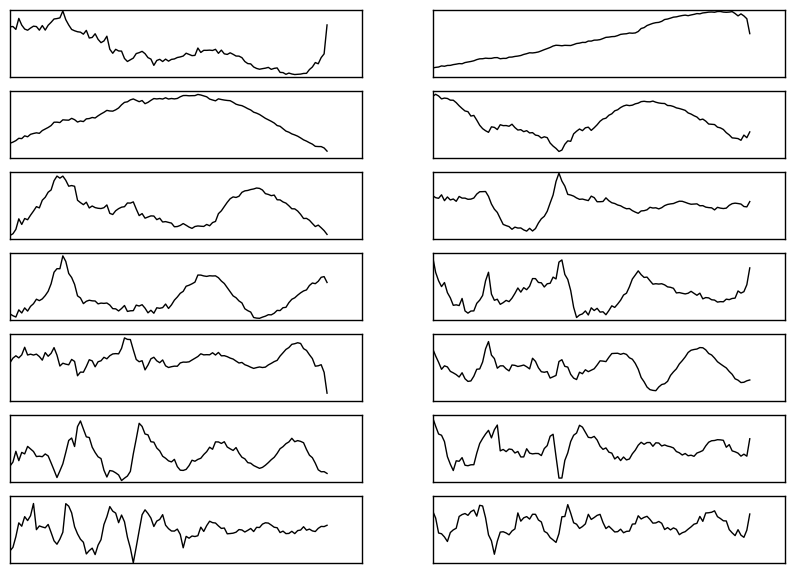

```julia
k = 14

figure(figsize = (10,1.0*k))

for i = 1:k
    subplot(k,2,i)
    plot(U[:,i],"k")
    #title("$(round(norm(D[:,i]),2))")
    tick_params(axis="x",bottom="off",top="off",labelbottom="off")
    tick_params(axis="y",right="off",left="off",labelleft="off")
end
```

Some trends are clear, but the results aren't quite as distinct as I'd like them to be. The components bear a unfortunate resemble to fourier basis, with low frequencies at the top, and high frequencies at the bottom. Not surprising since we're dealing with time series data. These features aren't quite as informative as I'd like them to be.

Enter [Non-Negative Matrix Factorization](https://en.wikipedia.org/wiki/Non-negative_matrix_factorization). Because the components can only interact constructively, I intuited it would get round the problem.

I played around with a few [Julia Libraries](https://github.com/JuliaStats/NMF.jl), but to my dissapointment many of the algorithms do not converge properly. The best results were obtained by just coding the whole thing in proximal gradient by hand.

```julia
k = 8
n = size(X,1)
m = size(X,2)

# Inverse of the vector operator
function ivec(z)
    D = reshape(z[1:n*k], n,k)
    E = reshape(z[n*k + 1:end], m,k)
    return (D,E)
end

T = Tridiagonal(-ones(n-1), 2*ones(n), -ones(n-1))

# Gradient of objective function
function f(z, arg = 0, α = 1., β = 0.1)
    (D,E) = ivec(z)
    R = X - D*E'
    fx = (vecnorm(R)^2)/2
    ∇gD = R*E
    ∇gE = R'*D
    return (fx, -[∇gD[:] - α*D[:] - β*(T*D)[:]; ∇gE[:] - α*E[:]])
end;
```

A note. Proximal gradient doesn't work well, if just applied in a vanilla sense. But adding momentum changes the game completely. This phenomena is well documented in the deep learning literature, see [here](http://www.cs.toronto.edu/~fritz/absps/momentum.pdf), for example.

```julia
prox = (x) -> [max(0, x[1:n*k]); max(0,x[n*k+1:end])]

x = 2*randn((n+m)*k)
y = zeros((n+m)*k)
t = 0.0001;
CONV = []

for i = 1:200*1
    (fy, ∇fy) = f(y)
    x = prox(x - t*∇fy)
    y = 0.95*y + x
    push!(CONV, fy)
end
```

Let's take a moment of silence to the loss go down.

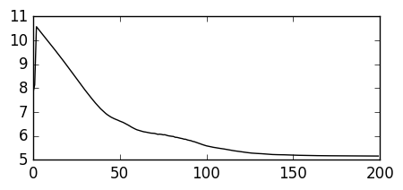

```julia
figure(figsize = (5,2))
plot(log(10,map(Float64,CONV)), "k");
```

Let's take a look at the dictionaries.

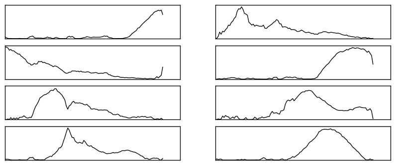

```julia
(D,E) = ivec(y)

figure(figsize = (10,1.0*k))

for i = 1:k
    subplot(k,2,i)
    plot(D[:,i],"k")
    #title("$(round(norm(D[:,i]),2))")
    tick_params(axis="x",bottom="off",top="off",labelbottom="off")
    tick_params(axis="y",right="off",left="off",labelleft="off")
end
```

Ahh. much better.

The spikes, in fact, have a clear interpretation. The left axis corrosponds to the year 1900, and the right to 2000. Therefore this puts two prominent spikes in, you guessed it, world war I and II.

```julia
writedlm("../data/Dstar", D)
writedlm("../data/Estar", E)
```

And now comes the tweaking. This little gap in the notebook represents about 2 weeks of work. Mostly tweaking parameters like $k$ and smoothing. I have a perchant for watching numbers go down.

I'd like to think that time was spent in a worthwhile way. But to be perfectly honest, it didn't help that much. The dictionary elements don't look all that different from the ones I started off with.

But here's something I prepared earlier anyway.

```julia
D = readdlm("../data/Dstar")
E = readdlm("../data/Estar");
```

How well does the model fit the data? Much better than hoped.

As it turns out, there are very striking regularities in the way words come in and out of being. With a few hundred exceptions to the rule, the model works beautifully.

But let's take a look at some of the entires which have the worst fit

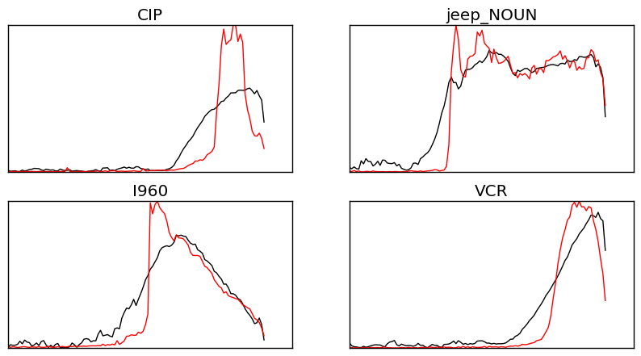

```julia
(D,E) = ivec(y)

# Sort by goodness of fit.
w = flipdim(sortperm(sum(abs(D*E' - X),1)[:]),1)
i = size(X,2)-20


fig = figure(figsize=(10, 5))

j = 1
for i = [1,9,19,25]
    subplot(2,2,j)
    plot(D*E[w[i],:]',"k")
    plot(X[:,w[i]],"r")
    title(Words[w[i]]);
    tick_params(axis="x",bottom="off",top="off",labelbottom="off")
    tick_params(axis="y",right="off",left="off",labelleft="off")
    j = j + 1
end
```

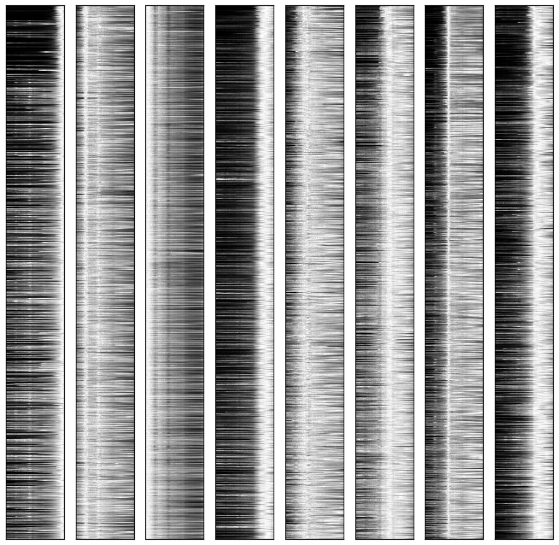

```julia
figure(figsize = (12,20*5))
for d_elem = 1:8
    subplot(1,8,d_elem)
    w = flipdim(sortperm(E[:,d_elem]),1)
    imshow(X[:,w][:,1:1000]', cmap = "gray")
    tick_params(axis="x",bottom="off",top="off",labelbottom="off")
    tick_params(axis="y",right="off",left="off",labelleft="off")
end
```

The visualization was starting to come together. But it finally clicked when I saw this Joy Division album [cover](http://rosvot.fi/wp/wp-content/uploads/2014/03/lp4572_big-goeland.fr_.jpg).

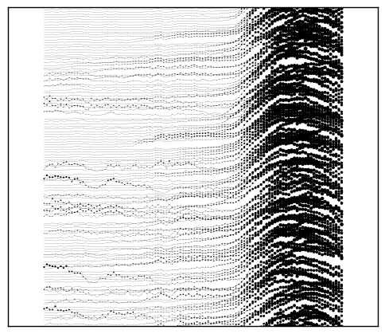

```julia
Ê = E./(sum(E,1))

w = flipdim(sortperm(E[:,4]),1)
figure(figsize = (6,5))

ln = nothing

t = 0.4
Re = t*(D*E') + (1-t)*X

for i = 1:150
    ln = 1.3*(Re[1:108,w[i]] - minimum(X[:,w[i]]))
    ln = 250*(ln./norm(ln,1))
    plot(10*ln  - 4*i,"k",linewidth = 0.1)
    scatter(collect(0:107),
            10*ln - 4*i,
            abs(ln).^(1.5)/2,
            "k",
            edgecolors="none")
end

tick_params(axis="x",bottom="off",top="off",labelbottom="off")
tick_params(axis="y",right="off",left="off",labelleft="off")
axis((-13.0,120.0,-500.0,0));
```